# INFO FINAL - Global COVID 19 Trends

Simran Gupta, Tilly Word, Jacqueline Heidy, Eden Fenta, Nolawi Woldemariam

2024-08-12

```r
library(readr)
library(dplyr)
```

```r
library(ggplot2)
library(tidyverse)
```

# ABSTRACT

We combined COVID-19 and World population datasets, focusing on the year 2020. We hypothesized that there would be a strong positive correlation between the population size and number of COVID-19 cases across the countries. However our findings directly contradicts our hypothesis, rather we found that low population density had higher COVID-19 cases. Furthermore, there were some countries that deviated from this trend, indicating outside factors - such as government response, healthcare infrastructure, and cultural practices - that have significantly contributed to the spread of COVID-19.

# INTRODUCTION

The COVID-19 pandemic affected the entirety of the world without discrimination. It is transmitted through human contact and escalated in mid-January of 2020. Many aspects of our lives were altered, such as social distancing, working/schooling from home, heightened cleanliness, and business closures. Additionally, as the pandemic progressed, numerous side effects from the virus, such as pneumonia, were discovered. However, there was no clear understanding of the causes or which existing vaccines were effective.

COVID is an interesting yet complicated topic, and our team set out to delve deeper and understand how COVID impacts each country by analyzing their confirmed rate, death rate, and recovery rate. We believe that countries with larger populations, like India, China, or the US, would have a much higher confirmed rate compared to smaller populations like Haiti. Although this was an assumption we had, we wanted to look into data supported by Kaggle to see if this was true. Many leaders across the world had contradicting views and various policies on how to contain their confirmed rates. Collectively, we wanted to investigate this further. We believe this information can be valuable to the public, global healthcare policy makers/healthcare workers, and organizations such as CDC/WHO to better understand how COVID has impacted the world—a very prominent topic that still affects us today, four years later.

Despite the fact that we all come from diverse backgrounds and have different lives, we found ourselves connected by our shared experience of the pandemic. Jackie lived in Jakarta, Indonesia, the nation’s capital in Southeast Asia. Jakarta is a heavily populated city with a population of 271,857,970 (2020). On the contrary, Simran lived in a small suburban town in the Bay Area, whereas Eden, Nolawi, and Tilly live in the heart of the pacific northwest, Seattle. During the pandemic, social distancing differed for each of us, as for vaccine mandates, health guidelines, etc. It sparked our initial interest to interpret and compare COVID rates and population in our final project for INFO 201.

HERE ARE OUR RESEARCH QUESTIONS:

How does a country’s population impact COVID-19 trends (active cases)?

What is the correlation between active cases and deaths per region?

How does variation in population density (low to high) play a role in COVID-19 policies?

What is the correlation between recovery rate and deaths per region?

What is the correlation between recovery rate and population density?

# DATASETS

### DATASET BACKGROUND

We chose the World Population dataset and COVID-19 dataset because they are able to answer our research questions. The COVID-19 dataset provides a daily report on the pandemic’s progression globally, which allows us to analyze trends in confirmed cases, deaths, recoveries, and active cases across different countries. The World Population dataset is pivotal for understanding how population size and density could influence these trends, allowing us to correlate and draw conclusions about the effects of population density on the spread of COVID-19 globally.

Both the COVID-19 and World Population datasets are easily accessible on the website Kaggle and are within the public domain. The actual dataset for World Population originated from the US Census Bureau, the Federal Statistical System, that is responsible for compiling and producing data about the US population and economy. While the COVID-19 dataset originated from the Johns Hopkins University whose Center for Systems Science and Engineering (CSSE) collected and compiled the COVID-19 data from multiple national and international health organizations. Both sets of data are from highly credible research based agencies.

## DATASET 1: COVID-19 DATASET

The COVID-19 dataset includes variables such as country/region, the number of confirmed cases, deaths, recoveries, active cases, new cases, new deaths, new recoveries, deaths per 100 cases, and recoveries per 100 cases. This data provides insights into COVID-19 trends across different countries in 2020, allowing us to understand how death and recovery rates evolved over time and the correlation between active cases and deaths by region. Here is the link to the dataset: https://www.kaggle.com/datasets/imdevskp/corona-virus-report

```r
# Filter out Datasets (by -Inf) --> Canada, Mozambiq, Serbia, Sweden, Syria
# Reload the original dataset
overalldataset <- read.csv('country_wise_latest.csv', sep = ",", header = TRUE)

# Check if "inf" exists in the "Deaths/100 Recovered" column
# sum(overalldataset$`Deaths...100.Recovered` == "Inf")
overalldataset <- overalldataset[overalldataset$`Deaths...100.Recovered` != "Inf", ]

# Change US to United States
overalldataset$Country.Region[overalldataset$Country.Region == "US"] <- "United States"
head(overalldataset)
```

```
##        Country.Region Confirmed Deaths Recovered Active New.cases New.deaths
## 1         Afghanistan     36263   1269     25198   9796       106         10
## 2             Albania      4880    144      2745   1991       117          6
## 3             Algeria     27973   1163     18837   7973       616          8
## 4             Andorra       907     52       803     52        10          0
## 5              Angola       950     41       242    667        18          1
## 6 Antigua and Barbuda        86      3        65     18         4          0
##   New.recovered Deaths...100.Cases Recovered...100.Cases Deaths...100.Recovered
## 1            18               3.50                 69.49                   5.04
## 2            63               2.95                 56.25                   5.25
## 3           749               4.16                 67.34                   6.17
## 4             0               5.73                 88.53                   6.48
## 5             0               4.32                 25.47                  16.94
## 6             5               3.49                 75.58                   4.62
##   Confirmed.last.week X1.week.change X1.week...increase            WHO.Region
## 1               35526            737               2.07 Eastern Mediterranean
## 2                4171            709              17.00                Europe
## 3               23691           4282              18.07                Africa
## 4                 884             23               2.60                Europe
## 5                 749            201              26.84                Africa
## 6                  76             10              13.16              Americas
```

## DATASET 2: WORLD POPULATION

The World Population dataset examines the population of each country/territory in 2020, enabling us to explore how a country’s population density might impact COVID-19 trends. Here is the link to the dataset: https://www.kaggle.com/datasets/iamsouravbanerjee/world-population-dataset

```r
# Load Second Dataset
populationdataset<- read.csv('world_population.csv', sep = ",", header = TRUE)
head(populationdataset)
```

```
##   Rank CCA3 Country.Territory          Capital Continent X2022.Population
## 1   36  AFG       Afghanistan            Kabul      Asia         41128771
## 2  138  ALB           Albania           Tirana    Europe          2842321
## 3   34  DZA           Algeria          Algiers    Africa         44903225
## 4  213  ASM    American Samoa        Pago Pago   Oceania            44273
## 5  203  AND           Andorra Andorra la Vella    Europe            79824
## 6   42  AGO            Angola           Luanda    Africa         35588987
##   X2020.Population X2015.Population X2010.Population X2000.Population
## 1         38972230         33753499         28189672         19542982
## 2          2866849          2882481          2913399          3182021
## 3         43451666         39543154         35856344         30774621
## 4            46189            51368            54849            58230
## 5            77700            71746            71519            66097
## 6         33428485         28127721         23364185         16394062
##   X1990.Population X1980.Population X1970.Population Area..km..
## 1         10694796         12486631         10752971     652230
## 2          3295066          2941651          2324731      28748
## 3         25518074         18739378         13795915    2381741
## 4            47818            32886            27075        199
## 5            53569            35611            19860        468
## 6         11828638          8330047          6029700    1246700
##   Density..per.km.. Growth.Rate World.Population.Percentage
## 1           63.0587      1.0257                        0.52
## 2           98.8702      0.9957                        0.04
## 3           18.8531      1.0164                        0.56
## 4          222.4774      0.9831                        0.00
## 5          170.5641      1.0100                        0.00
## 6           28.5466      1.0315                        0.45
```

## METHODS: MERGED BOTH DATASETS

```r
# Check column names & Merge Datasets
colnames(populationdataset)[which(names(populationdataset) == "Country.Territory")] <- "Country.Region"
head(populationdataset)
```

```
##   Rank CCA3 Country.Region          Capital Continent X2022.Population
## 1   36  AFG    Afghanistan            Kabul      Asia         41128771
## 2  138  ALB        Albania           Tirana    Europe          2842321
## 3   34  DZA        Algeria          Algiers    Africa         44903225
## 4  213  ASM American Samoa        Pago Pago   Oceania            44273
## 5  203  AND        Andorra Andorra la Vella    Europe            79824
## 6   42  AGO         Angola           Luanda    Africa         35588987
##   X2020.Population X2015.Population X2010.Population X2000.Population
## 1         38972230         33753499         28189672         19542982
## 2          2866849          2882481          2913399          3182021
## 3         43451666         39543154         35856344         30774621
## 4            46189            51368            54849            58230
## 5            77700            71746            71519            66097
## 6         33428485         28127721         23364185         16394062
##   X1990.Population X1980.Population X1970.Population Area..km..
## 1         10694796         12486631         10752971     652230
## 2          3295066          2941651          2324731      28748
## 3         25518074         18739378         13795915    2381741
## 4            47818            32886            27075        199
## 5            53569            35611            19860        468
## 6         11828638          8330047          6029700    1246700
##   Density..per.km.. Growth.Rate World.Population.Percentage
## 1           63.0587      1.0257                        0.52
## 2           98.8702      0.9957                        0.04
## 3           18.8531      1.0164                        0.56
## 4          222.4774      0.9831                        0.00
## 5          170.5641      1.0100                        0.00
## 6           28.5466      1.0315                        0.45
```

```r
overall_countries <- unique(overalldataset$Country.Region)
population_countries <- unique(populationdataset$Country.Region)
common_countries <- intersect(overall_countries, population_countries)
non_matching_covid_countries <- setdiff(overall_countries, population_countries)
overalldataset <- overalldataset[overalldataset$Country.Region %in% common_countries, ]
merged_data <- merge(overalldataset, populationdataset, by = "Country.Region", all.x = TRUE)
head(merged_data)
```

```
##        Country.Region Confirmed Deaths Recovered Active New.cases New.deaths
## 1         Afghanistan     36263   1269     25198   9796       106         10
## 2             Albania      4880    144      2745   1991       117          6
## 3             Algeria     27973   1163     18837   7973       616          8
## 4             Andorra       907     52       803     52        10          0
## 5              Angola       950     41       242    667        18          1
## 6 Antigua and Barbuda        86      3        65     18         4          0
##   New.recovered Deaths...100.Cases Recovered...100.Cases Deaths...100.Recovered
## 1            18               3.50                 69.49                   5.04
## 2            63               2.95                 56.25                   5.25
## 3           749               4.16                 67.34                   6.17
## 4             0               5.73                 88.53                   6.48
## 5             0               4.32                 25.47                  16.94
## 6             5               3.49                 75.58                   4.62
##   Confirmed.last.week X1.week.change X1.week...increase            WHO.Region
```

[output cut: 34 more lines]

```r
# Filtering columns not needed in Merged Dataset
finaldataset <- merged_data[, c("Country.Region", "Confirmed", "Deaths", "Recovered", "Active", "New.cases", "New.deaths", "New.recovered", "Deaths...100.Cases", "Recovered...100.Cases", "Deaths...100.Recovered", "X2020.Population", "Density..per.km..")]
head(finaldataset)
```

```
##        Country.Region Confirmed Deaths Recovered Active New.cases New.deaths
## 1         Afghanistan     36263   1269     25198   9796       106         10
## 2             Albania      4880    144      2745   1991       117          6
## 3             Algeria     27973   1163     18837   7973       616          8
## 4             Andorra       907     52       803     52        10          0
## 5              Angola       950     41       242    667        18          1
## 6 Antigua and Barbuda        86      3        65     18         4          0
##   New.recovered Deaths...100.Cases Recovered...100.Cases Deaths...100.Recovered
## 1            18               3.50                 69.49                   5.04
## 2            63               2.95                 56.25                   5.25
## 3           749               4.16                 67.34                   6.17
## 4             0               5.73                 88.53                   6.48
## 5             0               4.32                 25.47                  16.94
## 6             5               3.49                 75.58                   4.62
##   X2020.Population Density..per.km..
## 1         38972230           63.0587
## 2          2866849           98.8702
## 3         43451666           18.8531
## 4            77700          170.5641
## 5         33428485           28.5466
## 6            92664          212.1335
```

```r
# Adding Categorical Variable
finaldataset <- finaldataset %>%
  mutate(Density_Category = case_when(
    Density..per.km.. < 100 ~ "Low",
    Density..per.km.. >= 100 & Density..per.km.. < 500 ~ "Medium",
    Density..per.km.. >= 500 ~ "High"
  ))
finaldataset$Density_Category <- cut(finaldataset$Density..per.km..,
                                     breaks = c(-Inf, 100, 500, Inf),
                                     labels = c("Low", "Medium", "High"))
```

Between the two datasets, Country.Region was our primary key as it is common in both datasets. Once we merged the datasets together, the variables we kept from dataset 1 (COVID-19 dataset) were Confirmed, Death, Recovered, Active, New.Cases, New.Deaths, New.Recovered, Deaths…100 Cases, Recovered.1000 Cases, and Deaths…100.Recovered. This was combined with the X2020.Population and Density…per.km variables in dataset 2. We kept these variables because we wanted to specifically focus on COVID-19 trends in 2020 and how population density played a role in this. We processed data by ensuring that data is consistent and accurate while keeping an eye out for missing information. We selected sample by focusing on density and population from the world population dataset and correlating this with various COVID-19 factors. Like mentioned in the dataset section, we removed non-numeric values, and made sure country names were listed the same in both datasets (primary key). We didn’t use any complex methods though we made sure to show our data visually through scattergraphs, histograms, and tables to answer our research questions.

### SUMMARIZATION TABLE

```r
summary_table <- finaldataset %>%
  summarize(
    Total_Confirmed = sum(Confirmed, na.rm = TRUE),
    Total_Deaths = sum(Deaths, na.rm = TRUE),
    Total_Recovered = sum(Recovered, na.rm = TRUE),
    Total_Active = sum(Active, na.rm = TRUE),
    Avg_Deaths_per_100_Cases = mean(Deaths...100.Cases, na.rm = TRUE),
    Avg_Recovered_per_100_Cases = mean(Recovered...100.Cases, na.rm = TRUE),
    Avg_Deaths_per_100_Recovered = mean(Deaths...100.Recovered, na.rm = TRUE),
    Avg_Population_Density = mean(Density..per.km.., na.rm = TRUE)
  )
print(summary_table)
```

```
##   Total_Confirmed Total_Deaths Total_Recovered Total_Active
## 1        16193715       637769         9429696      6126250
##   Avg_Deaths_per_100_Cases Avg_Recovered_per_100_Cases
## 1                 3.061047                    66.60669
##   Avg_Deaths_per_100_Recovered Avg_Population_Density
## 1                     42.76471               317.4383
```

## RESULTS

### 1. How does a country’s population impact COVID-19 trends?

```r
filtered_data <- finaldataset %>%
  filter(Country.Region %in% c("United States", "India", "Bangladesh"))
summary_table <- filtered_data %>%
   select(Country.Region, Confirmed, Deaths, Recovered, Active, Density..per.km..)
summary_table
```

```
##   Country.Region Confirmed Deaths Recovered  Active Density..per.km..
## 1     Bangladesh    226225   2965    125683   97577         1160.0350
## 2          India   1480073  33408    951166  495499          431.0675
## 3  United States   4290259 148011   1325804 2816444           36.0935
```

Even through the US has low population density they had the highest confirmed COVID-19 cases in comparison to India and Bangladesh whose population density is significantly higher. This illustrates that density may not be a large factor in predicting active cases. Outside influences like government policies and health infrastructure may have affected the active cases in countries like the US where mask mandates weren’t enforced.

### 2. What is the correlation between active cases and deaths per region?

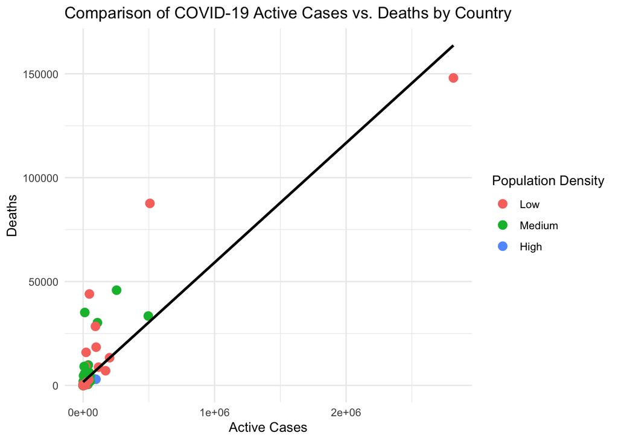

```r
correlation <- cor(finaldataset$Density..per.km.., finaldataset$Recovered...100.Cases, use = "complete.obs")
ggplot(finaldataset, aes(x = Active, y = Deaths, color = Density_Category)) +
  geom_point(size = 3) +
  geom_smooth(method = "lm", se = FALSE, color = "black") +
  labs(
    title = "Comparison of COVID-19 Active Cases vs. Deaths by Country",
    x = "Active Cases",
    y = "Deaths",
    color = "Population Density"
  ) +
  theme_minimal()
```

```r
annotate("text", x = max(finaldataset$Active) * 0.9, y = max(finaldataset$Deaths) * 0.9, label = paste("r =", round(correlation, 2)), size = 5, color = "black")
```

[output not shown]

### 3. How does variation in population density (low to high) play a role in COVID-19 policies?

[figure not shown]

```r
ggplot(finaldataset, aes(x = Density_Category, y = Active, fill = Density_Category)) +
  geom_bar(stat = "identity") +
  labs(
    title = "Average Active COVID-19 Cases by Population Density Category",
    x = "Population Density Category",
    y = "Average Active Cases",
    fill = "Population Density Category"
  ) +
  theme_minimal()
```

### 4. What is the correlation between recovery rate and deaths per region?

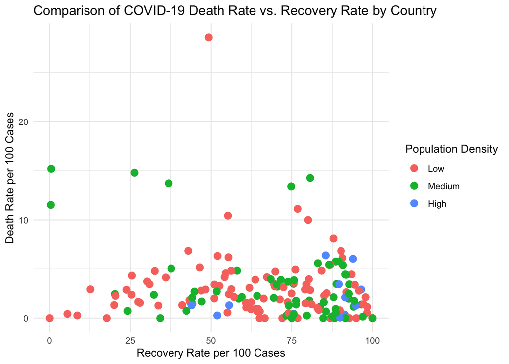

```r
ggplot(finaldataset, aes(x = Recovered...100.Cases, y = Deaths...100.Cases, color = Density_Category)) +
  geom_point(size = 3) +
  labs(
    title = "Comparison of COVID-19 Death Rate vs. Recovery Rate by Country",
    x = "Recovery Rate per 100 Cases",
    y = "Death Rate per 100 Cases",
    color = "Population Density"
  ) +
  theme_minimal()
```

Countries with higher population density show a higher recovery rate and a lower death rate. While lower or medium population densities have higher death rates and lower recovery rates. This trend suggests that government policies, including healthcare infrastructure and public health measures, may have played a role in influencing these outcomes.

### 5. What is the correlation between recovery rate and population density?

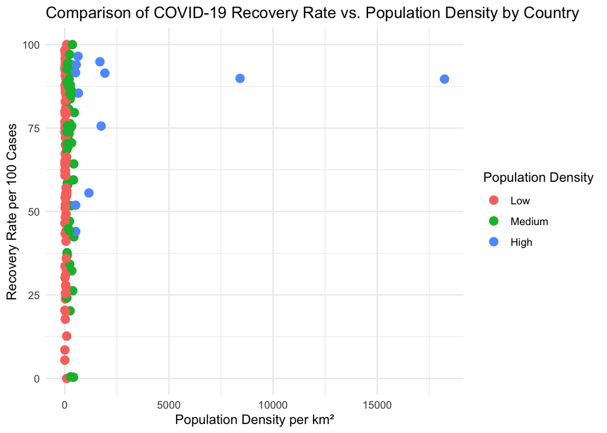

```r
ggplot(finaldataset, aes(x = Density..per.km.., y = Recovered...100.Cases, color = Density_Category)) +
  geom_point(size = 3) +
  labs(
    title = "Comparison of COVID-19 Recovery Rate vs. Population Density by Country",
    x = "Population Density per km²",
    y = "Recovery Rate per 100 Cases",
    color = "Population Density"
  ) +
  theme_minimal()
```

We originally believed that countries with a lower population density would have a higher recovery rate however that is false with this data. We can’t predict whether a given population density better impacts the recovery rate as it differs by country specifically. Low population density had a low recovery rate but also shown with a high recovery rate (this has to do with policies, health infrastructure, underreporting of COVID cases.

## DISCUSSION

According to the National Library of Medicine, the U.S. had lax protocol measures, which led to widespread infection. In contrast, countries like India and Bangladesh, despite their high population densities, had a fewer active COVID-19 case rate. These governments enacted social distancing measures swiftly and strictly, helping to prevent the rapid spread of the virus. Factors such as healthcare infrastructure and government regulations significantly impacted our data. However, we can’t be so certain about these results because these countries also had limited financial resources and poor healthcare which led to underreporting of COVID-19 cases throughout the country. Additionally, people were weary about even testing/reporting their positive case to the government. In the future, we could focus specifically on policies per country to exactly understand how COVID numbers fluctuate based on governmental regulations.

## SUMMARY

All in all, we were surprised by our findings and gained far more insights than we initially expected. Countries that acted quickly by implementing protective measures, even with high population density, managed to keep active cases lower. The most significant takeaway from this study is the importance of quick action in the face of a crisis.

We learned that the countries that had a higher density population had the lowest confirmed and death cases. Actions were taken immediately which helped reduce the spread of the virus. Compared to the countries that had the lower density population which had higher confirmed and death cases. We also noticed that these countries also had lower recovery rates.